# Lab 9: Статистические тесты

Не забываем загружать пакеты, которые нужны для работы

```r
library(ggplot2)
library(dplyr)
```

### По мотивам лекции

Загрузим данные про оценки по математике и социологии для экономистов и социологов (+ перцентиль в соответствующем рейтинге, нормированная оценка, специальность и запись на майнор)

```r
rates <- read.csv("~/shared/minor2_2016/lab09-tests/rates.csv")
```

Посмотрим на разницу в оценках по графикам. Что можно сказать?

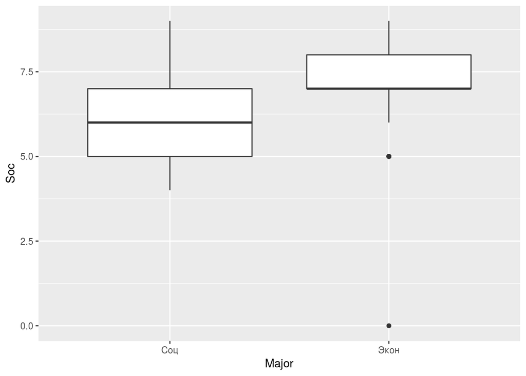

```r
ggplot(rates) +
  geom_boxplot(aes(x=Major, y=Soc))
```

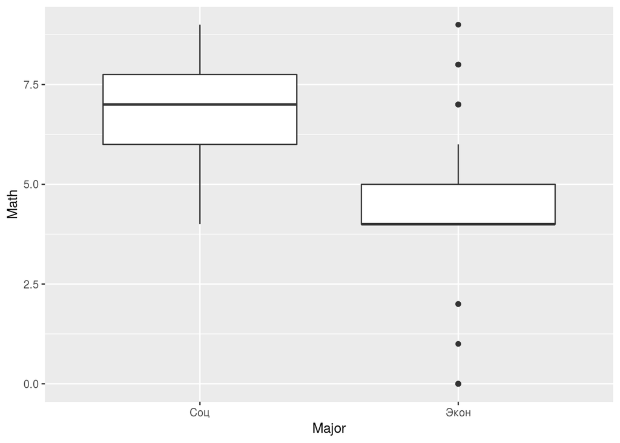

```r
ggplot(rates) +
  geom_boxplot(aes(x=Major, y=Math))
```

Вычислим разность средних оценок явным образом (для отличия от лекции – по социологии)

```r
All_means <- group_by(rates, Major) %>%
  summarize(Math.observed = mean(Math), Soc.observed = mean(Soc))
All_means
```

```
## # A tibble: 2 × 3
##    Major Math.observed Soc.observed
##   <fctr>         <dbl>        <dbl>
## 1    Соц      6.755319     6.223404
## 2   Экон      4.635838     6.994220
```

```r
diff.observed <- All_means$Soc.observed[1] - All_means$Soc.observed[2]
diff.observed
```

```
## [1] -0.7708154
```

Можем ли мы сказать велика ли разница?

### Гипотеза

Попробуем понять, есть какая-то закономерность приводящая к разнице оценок, или это всего лишь случайность.

1. Сформулируем наш вопрос на языке статистики (то есть определим $H_0$ и $H_A$)
   - Например: $H_0:$ Средняя оценка по социологии одинаковая для экономистов и социологов; $H_A:$ Средние оценки различаются.
2. Выберем уровень значимости ($\alpha$ – допустимая вероятность **ошибочно** отклонить **истинную** $H_0$)
3. Определим подходящую к нашим данным статистику и вычислим ее.
4. Проверим, достаточно ли у нас оснований отклонить нулевую гипотезу (для выбранного значения $\alpha$)
5. Сформулируем наши выводы на “человеческом” языке.

### Random Permutation Test

Вспомним разницу в средней оценке которую мы наблюдали: -0.7708154

**При тестировании мы предполагаем, что нуль-гипотеза истинна.**

Давайте посмотрим как разность будет себя вести в разных случаях. Напомню, мы предполагаем, что в среднем разницы нет. Тогда если мы перемешаем наши оценки и раздадим их случайно, то особо ничего измениться не должно.

Давайте случайно перемешивать оценки и записывать разницу между средней оценкой социологов и средней оценкой экономистов.

```r
number_of_permutations <- 5000

count_diff <- function(number_of_permutations = 1000) {
  diff.random <- rep(NA_real_, number_of_permutations) # вектор с неопределенными (пустыми) значениями,
                                                      # в который будем записывать вычисленные разницы
  for (i in 1 : number_of_permutations) {

    # перемешиваем оценки
    shuffled = sample(rates$Soc, length(rates$Soc))

    # выбираем те оценки, что после перемешивания оказались у социологоы
    Soc.random = shuffled[rates$Major == "Соц"]
    # выбираем те оценки, что после перемешивания оказались у экономистов
    Econ.random = shuffled[rates$Major == "Экон"]

    # вычисляем разность средних
    diff.random[i] = mean(Soc.random) - mean(Econ.random)
  }
  return(diff.random)
}
```

Генерируем случайные перестановки и любуемся картинками

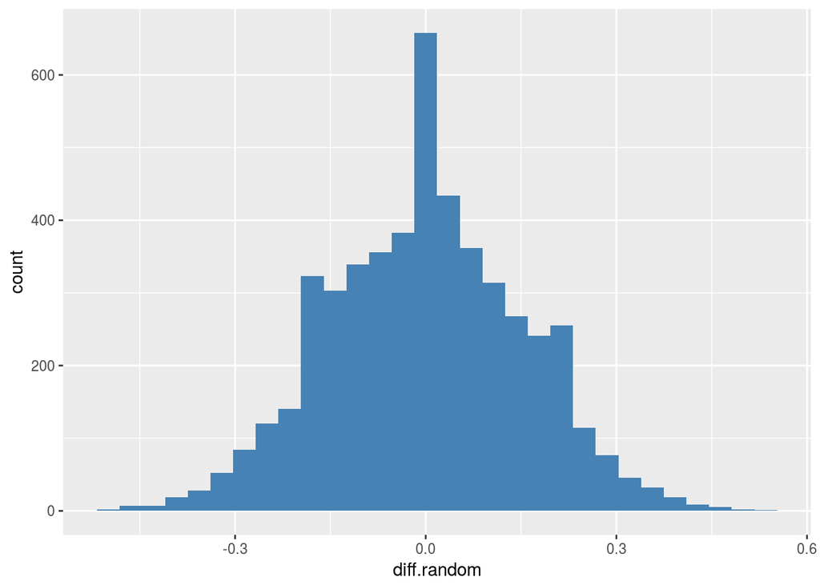

Добавим разность которую мы наблюдали

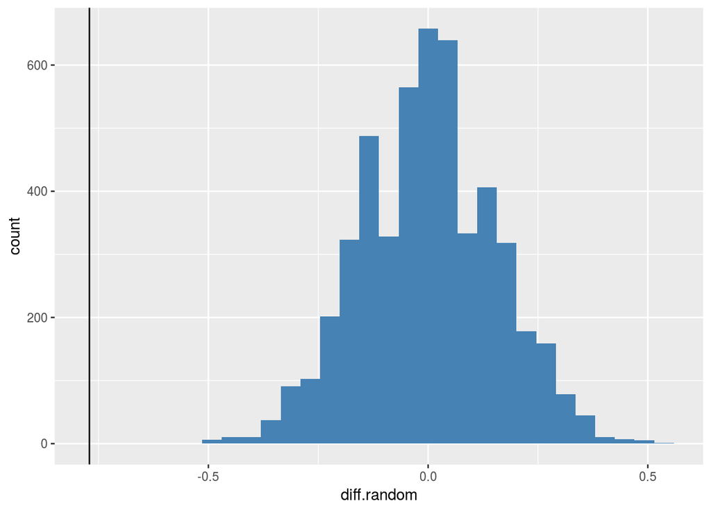

Добавим 5% критическую область

```r
q <- quantile(diff.random, c(0.025, 0.975))
```

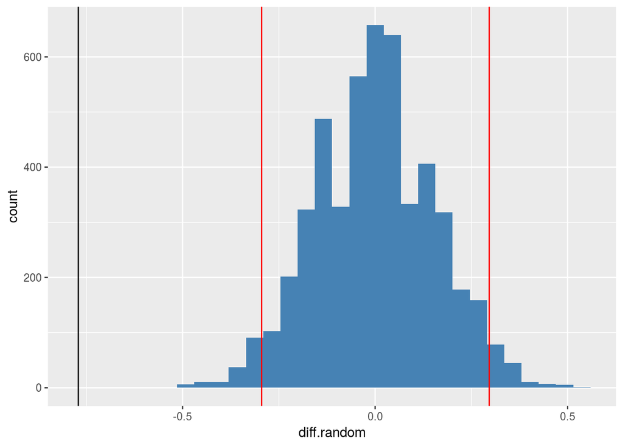

Что такое **p-value**? (см. лекцию)

Посчитаем количество перестановок у которых разность была больше и поделим на общее число экспериментов.

```r
pvalue = sum(abs(diff.random) >= abs(diff.observed)) / number_of_permutations
pvalue
```

```
## [1] 0
```

- Какой вывод можно сделать?

## t-критерий

Сравним абсолютные оценки у пришедших и не пришедших на майнор

```r
t.test(abs~DS_minor, data = rates)
```

```
##
##  Welch Two Sample t-test
##
## data:  abs by DS_minor
## t = -4.8441, df = 185.56, p-value = 2.674e-06
## alternative hypothesis: true difference in means is not equal to 0
## 95 percent confidence interval:
##  -0.09112714 -0.03838270
## sample estimates:
## mean in group FALSE  mean in group TRUE
##           0.6455391           0.7102940
```

- Выводы?
- Проведите это же сравнение с помощью теста перестановок. Есть ли различия?

## Хи-квадрат

Есть ли взаимсовязь между выбором майнора и специальностью? Другими словами, влияет ли специальность на выбор майнора?

|  | FALSE | TRUE |
| --- | --- | --- |
| **Соц** | 59 | 35 |
| **Экон** | 122 | 51 |

Формальные результаты теста

```r
ch <- chisq.test(rates$Major, rates$DS_minor)
ch
```

```
##
##  Pearson's Chi-squared test with Yates' continuity correction
##
## data:  rates$Major and rates$DS_minor
## X-squared = 1.3409, df = 1, p-value = 0.2469
```

- Выводы?

Наблюдаемые и ожидаемые значения

```r
ch$observed
```

```
##            rates$DS_minor
## rates$Major FALSE TRUE
##        Соц     59   35
##        Экон   122   51
```

```r
ch$expected
```

```
##            rates$DS_minor
## rates$Major     FALSE     TRUE
##        Соц   63.72285 30.27715
##        Экон 117.27715 55.72285
```

Таблица Пирсоновских остатков

```r
ch$residuals
```

```
##            rates$DS_minor
## rates$Major      FALSE       TRUE
##        Соц  -0.5916382  0.8583142
##        Экон  0.4361111 -0.6326845
```

Отклонения от ожидаемого

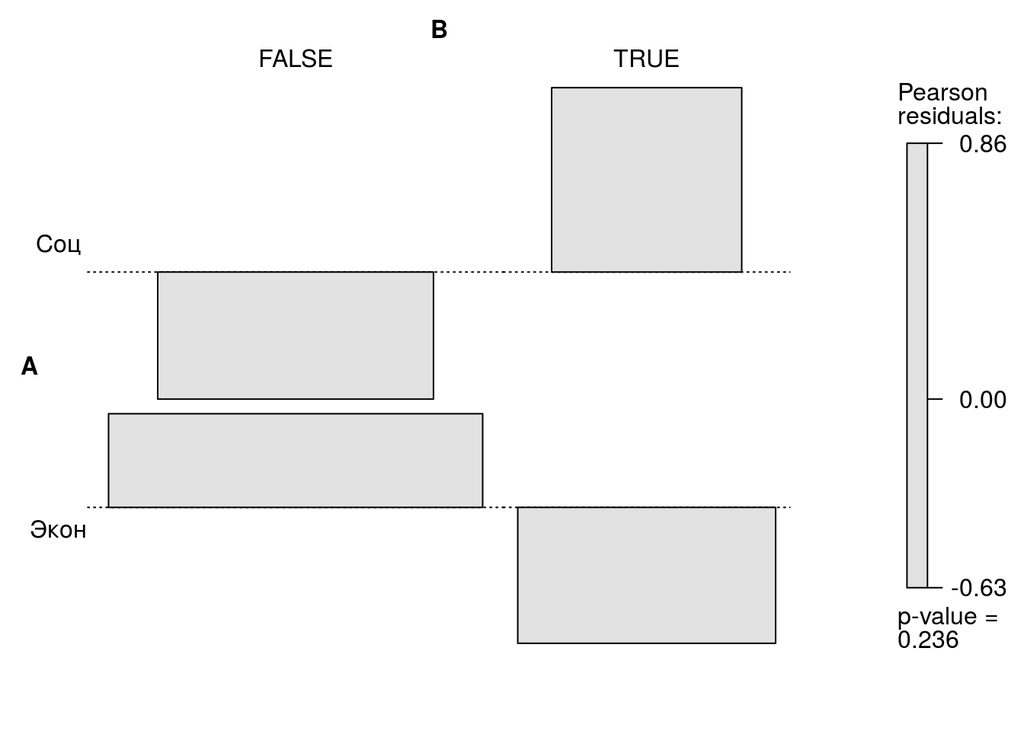

```r
library(vcd)
assoc(table(rates$Major, rates$DS_minor), gp=shading_max, rot_labels = c(0, 0, 0, 0), rot_varnames = c(0, 0, 0, 0))
```

Или же все вместе на одном графике (полезно, если таблицы больше, чем на 2 на 2)

```r
df_resid = as.data.frame(ch$residuals)
df_resid
```

```
##   rates.Major rates.DS_minor       Freq
## 1         Соц          FALSE -0.5916382
## 2        Экон          FALSE  0.4361111
## 3         Соц           TRUE  0.8583142
## 4        Экон           TRUE -0.6326845
```

```r
df_count = as.data.frame(ch$observed)
df_count
```

```
##   rates.Major rates.DS_minor Freq
## 1         Соц          FALSE   59
## 2        Экон          FALSE  122
## 3         Соц           TRUE   35
## 4        Экон           TRUE   51
```

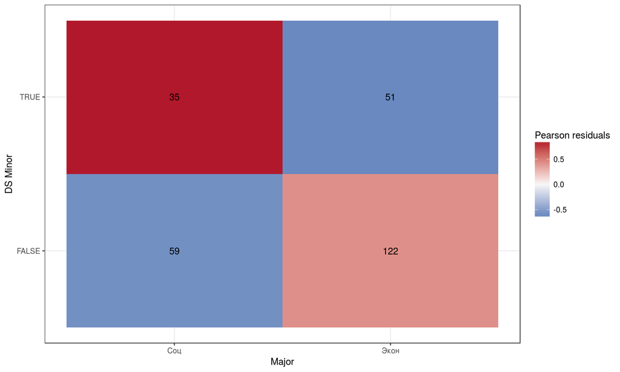

```r
ggplot() +
  geom_raster(data = df_resid, aes(x = rates.Major, y = rates.DS_minor, fill = Freq), hjust = 0.5, vjust = 0.5) +
  scale_fill_gradient2("Pearson residuals", low = "#2166ac", mid = "#f7f7f7", high = "#b2182b", midpoint = 0) +
  geom_text(data = df_count, aes(x = rates.Major, y = rates.DS_minor, label = Freq)) +
  xlab("Major") +
  ylab("DS Minor") +
  theme_bw()
```

## Ваша очередь

Загрузите базу по колледжам

```r
colleges = ISLR::College
?ISLR::College
```

Ответьте на вопросы, используя подходящие тесты. При ответе как минимум на два вопроса используйте одновременно тест перестановок и t-тест, сравните результаты. Обратите внимание, что для ответа на некоторые вопросы недостаточно исходных переменных, а нужно их преобразовать (посчитать доли, разделить на группы и т.д.)

- Есть ли взаимосвязь между числом подаваемых в колледж заявлений и его типом (частный - государственный)
- Отличаются ли частные и государственные колледжи по доле принятых заявлений
- Есть ли взаимосвязь между тем, что доля принятых заявлений составляет более 75%, и типом колледжа
- Есть ли взаимосвязь между числом студентов-бакалавров (F.Undergrad + P.Undergrad) и типом колледжа
- Отличаются ли частные и государственные колледжи по числу выпускников, оказывающих помощь (perc.alumni)
- Есть ли взаимосвязь между тем, что доля окончивших колледж (Grad.Rate) составляет более 50%, и его типом
- Есть ли взаимосвязь между тем, что на одного сотрудника приходится больше 15 студентов (S.F.Ratio), и типом колледжа
- Есть ли взаимосвязь между уровнем расходов на книги (Books) и типом колледжа
- Есть ли взаимосвязь между тем, что доля сотрудников с PhD составляет более 75%, и типом колледжа
- Разделите колледжи на 4 группы по доле принятых заявлений: 1) менее 65%, 2) от 65% до 75%, 3) от 75% до 85%, 4) более 85%. Есть ли взаимосвязь между принадлежностью к группе и типом колледжа
- … Ваши варианты вопросов